# Scienza dei dati Giochi olimpici estivi

## Dataset

Fonte: [kaggle.com](https://www.kaggle.com/datasets/heesoo37/120-years-of-olympic-history-athletes-and-results)

`athlete_events` :

Anno Città ospitante

Sesso Età Altezza Team

Sport Medaglia vinta

## Analisi esplorativa iniziale

## Numero di atleti nel tempo

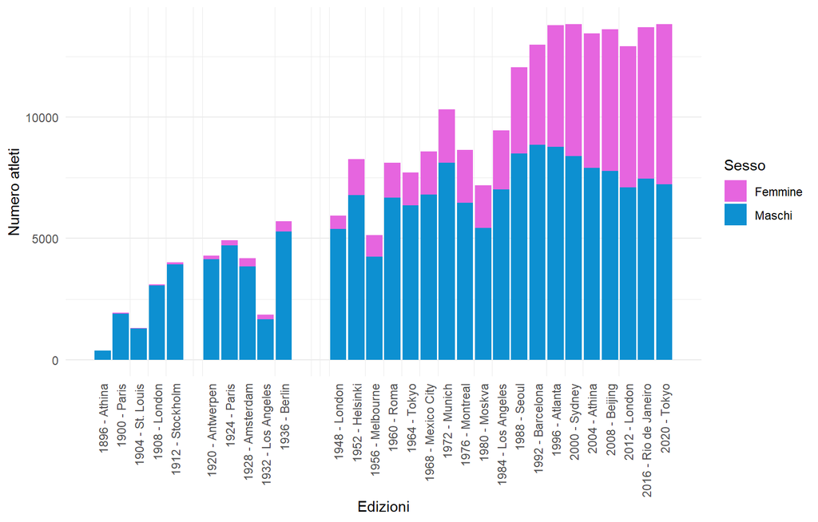

## Sport più giocati (1)

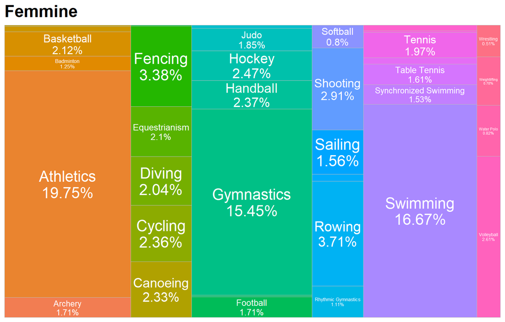

## Sport più giocati (2)

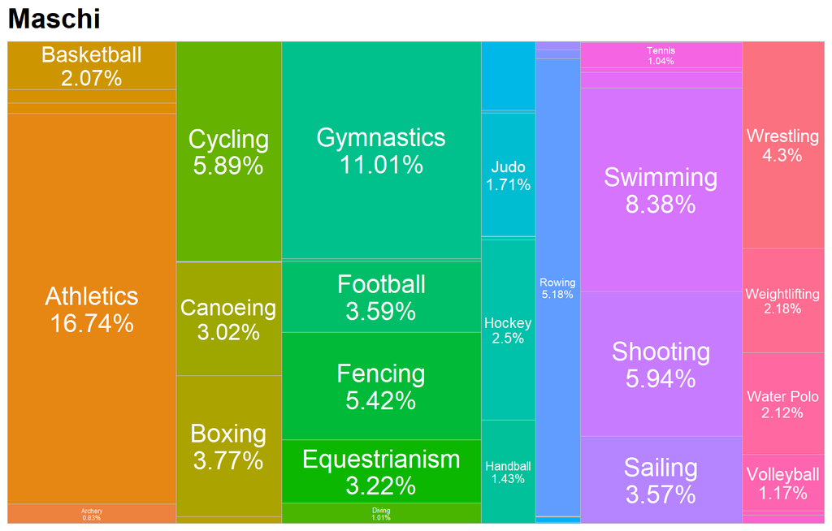

## Sport: NUOTO

## Quali sono i tratti fisici dei migliori atleti/e?

## Altezza - Atleti vincenti (1)

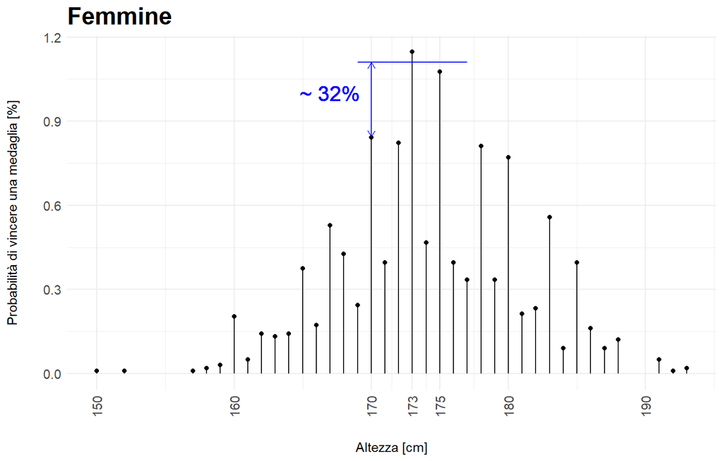

## Altezza - Atleti vincenti (2)

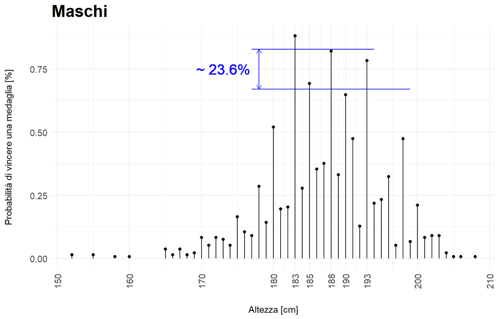

## Età - Atleti vincenti (1)

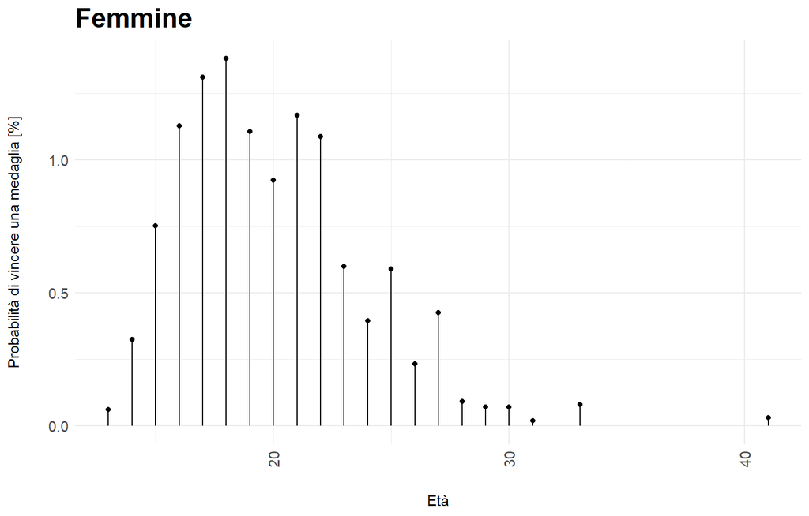

## Età - Atleti vincenti (2)

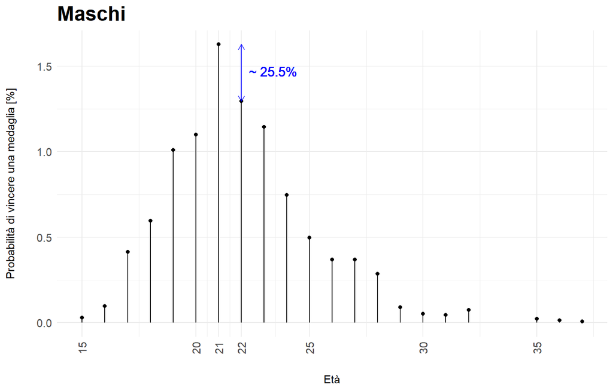

## Ritorno all’analisi esplorativa Medagliere italiano

## Medagliere Italia Team

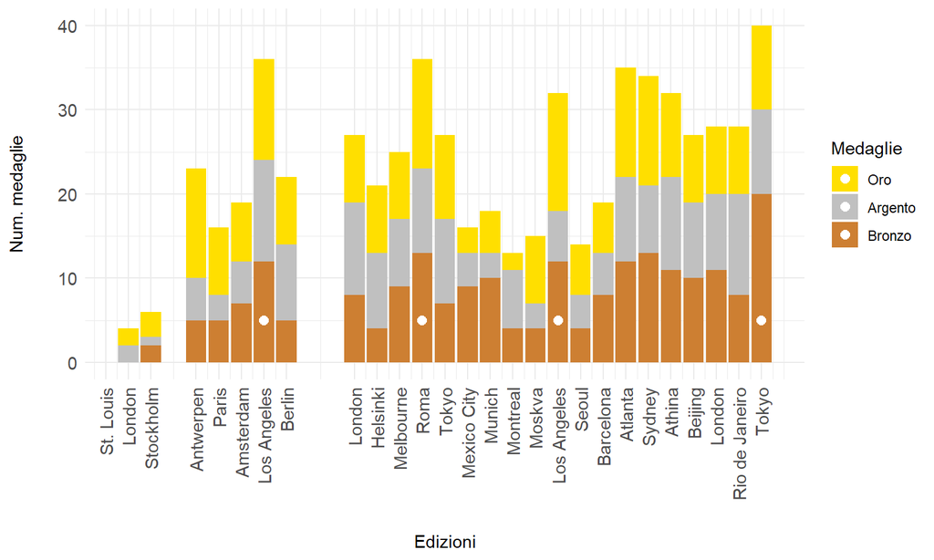

Trend positivo.  
*Ma, a cosa sono dovuti i picchi a Los Angeles, Roma e Tokyo?*

## Ipotesi sui picchi

1 - Differenza di temperatura rispetto all’Italia

2 - Distanza del paese ospite

## Dataset

Informazioni sul meteo dal 1932 per città

Fonte: [data.world](https://data.world/data-society/global-climate-change-data?dwr=US)

`GlobalLandTemperatureByMajorCity` :

Mese : Agosto Temperatura media

Latitudine città Longitudine città

## 1 - Differenza di temperatura

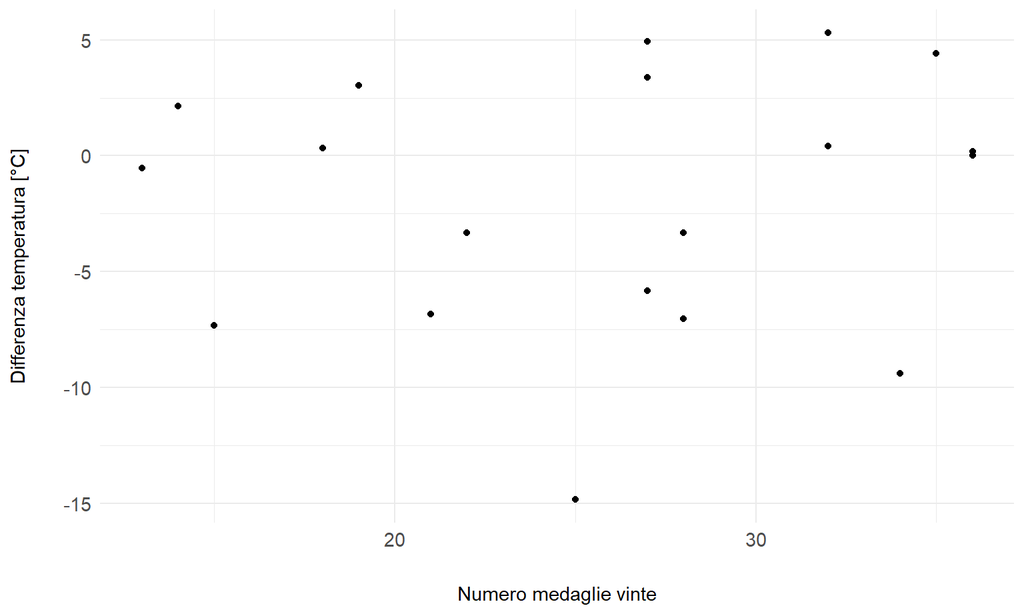

**Nessuna correlazione**. Indice di correlazione lineare : 0.0443884

## 2 - Distanza paesi

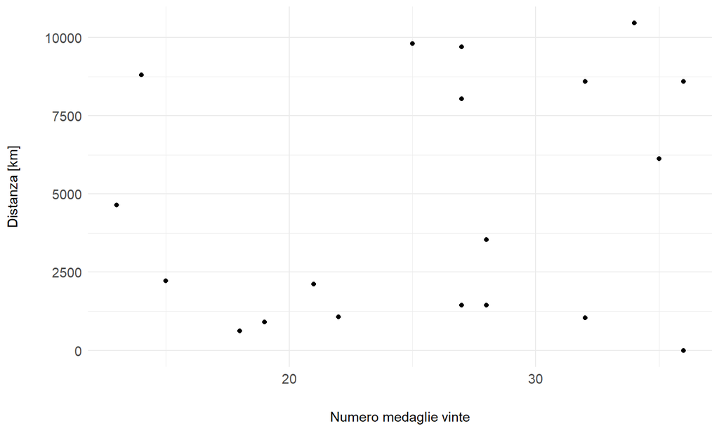

**Nessuna correlazione**. Indice di correlazione lineare : 0.1259575

## Medagliere - Correlazioni

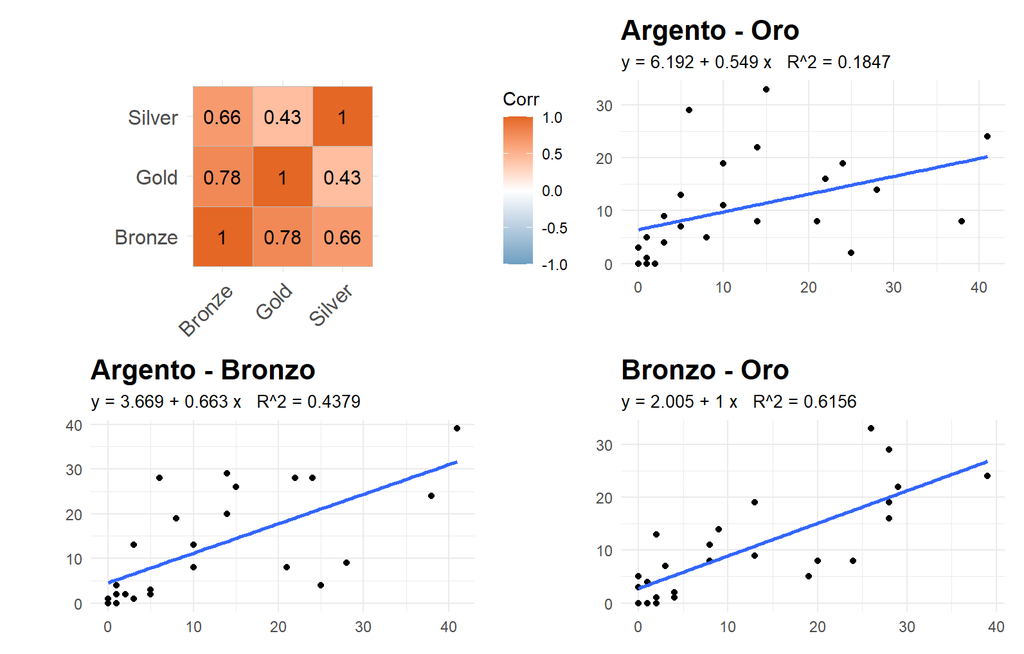

## Conclusioni

Analizzando i dati relativi ai Giochi olimpici estivi si osserva che da circa inizio anni 2000 il numero di partecipanti è pressoché stazionario, mentre le quote rose sono quasi alla parità; gli sport più giocati sono l’atletica, la ginnastica e il nuoto.

Per quanto concerne il nuoto, le caratteristiche fisiche dei vincitori come l’altezza e l’età sembrano avere una non poca importanza; permettendo una maggiore possibilità di vincita rispetto agli avversari (in media totale) del ~27%.  
Le migliori combinazioni secondo i dati sono:

- `Maschi = (Età : 21 anni , Altezza : 183, 188 e 193cm)`
- `Femmine = (Età : dai 16 ai 22 anni , Altezza : 173 e 175cm)`

Il medagliere dell’Italia Team presenta 4 picchi che non dipendono dalle ipotesi di differenza di temperatura o distanza del paese ospitante.  
Mentre, il numero di medaglie di bronzo e di oro sembrano essere legate dalla retta di regressione y = 2.005 + x con R^2 = 0.6156.